# R per l’analisi statistica multivariata

## Calcolo delle probabilità con **R**

In questa lezione ci occuperemo di calcolo delle probabilià. Per cominciare, introduciamo e calcoliamo in **R** alcuni quantità legate al calcolo combinatorio.

## Calcolo combinatorio

Il **fattoriale** di un numero $n$, indicato con $n!$ è il prodotto dei numeri da $1$ ad $n$, ovvero

$$n! = 1 \times 2 \times 3 \times \cdots \times n.$$
Questo valore in **R** si può ottenere in due modi:

```r
n <- 10

prod(1:n) # Prodotto dei termini da 1 a n
[1] 3628800
factorial(n) # Comando equivalente
[1] 3628800
```

In presenza di numeri molto grandi, il comando potrebbe restituire `Inf`. Supponiamo di essere interessati al calcolo di

$$\log{n!} = \sum_{i=1}^n\log{n}.$$

```r
n <- 10000
log(factorial(n)) # Risultato NON corretto
[1] Inf
sum(log(1:n)) # Risultato corretto
[1] 82108.93
lfactorial(n) # Comando equivalente
[1] 82108.93
```

### Coefficiente binomiale

Il coefficiente binomiale può essere ottenuto combinando i coefficienti fattoriali oppure utilizzando un comando apposito. Si ricordi che

$$\binom{n}{k} = \frac{n!}{k!(n-k)!}.$$

In **R** quindi otterremo

```r
n <- 10
k <- 4

factorial(n) / (factorial(k) * factorial(n - k)) # Coefficiente binomiale
[1] 210
choose(n, k) # Comando equivalente
[1] 210
```

## Variabili casuali in R

`R` dispone di un’estesa serie di funzioni dedicate alle principali distribuzioni di probabilità. Sia $X$ una variabile casuale.

- **d**dist (dove la “d” iniziale sta per *density*). Calcola la densità $f(x)$ di una variabile continua $X$ oppure la funzione di probabilità $p(x) = \mathbb{P}(X = x)$ nel caso $X$ sia discreta.
- **p**dist (dove la “p” iniziale sta per *probability*), che permette di calcolare il valore della funzione di ripartizione in un punto specificato, ovvero calcola $F(x) = \mathbb{P}(X \le x)$.
- **q**dist (dove la “q” iniziale sta per *quantile*), che rappresenta la funzione “inversa” della precedente, ovvero:
  $$\mathcal{Q}(p) = \inf\{x \in \mathbb{R} : F(x) \ge p\}, \qquad p \in (0,1).$$
  Nel caso di variabili aleatorie assolutamente continue, si ottiene quindi che $\mathcal{Q}(\cdot) = F^{-1}(\cdot)$.
- **r**dist (dove la “r” iniziale sta per *random*), che permette di generare numeri **pseudo-casuali** che seguono la distribuzione di probabilità di $X$.

| Distribuzione | Comando **R** | Parametri | Default |
| --- | --- | --- | --- |
| Binomiale | `binom` | `size`, `prob` | - |
| Geometrica | `geom` | `prob` | - |
| Poisson | `pois` | `lambda` | - |
| Uniforme | `unif` | `min`, `max` | `0`, `1` |
| Gamma | `gamma` | `shape`, `rate` | -, `1` |
| Esponenziale | `exp` | `rate` | `1` |
| Chi-quadrato | `chisq` | `df` | - |
| Normale | `norm` | `mean`, `sd` | `0`, `1` |

## Esempio: variabile casuale Binomiale

Sia $X \sim \text{Bin}(n, p)$ una variabile aleatoria binomiale, con $n = 10$ e $p = 0.6$. Si ricordi che

$$\mathbb{P}(X=k) = {n \choose k } p^k (1-p)^{n-k}, \qquad k=0,1,\dots,n.$$
Ad esempio, $\mathbb{P}(X=4)$ si calcola come segue

```r
n <- 10 # Numero di tentativi
p <- 0.6 # Probabilità di successo
k <- 4 # Numero di successi

choose(n, k) * p^k * (1 - p)^(n - k)
[1] 0.1114767
```

Lo stesso risultato si può ottenere tramite i comandi che abbiamo appena descritto, ovvero

```r
dbinom(k, size = n, prob = p)
[1] 0.1114767
```

### Funzione di ripartizione

In maniera simile, possiamo anche calcolare la probabilità seguente

$$\mathbb{P}(X \le 5) = \sum_{k=0}^5\mathbb{P}(X = k), \qquad X \sim \text{Bin}(10,0.6).$$

In **R** infatti possiamo usare, equivalentemente

```r
pbinom(5, size = n, prob = p)
[1] 0.3668967
sum(dbinom(0:5, size = n, prob = p))
[1] 0.3668967
```

Supponiamo di essere invece interessati all’evento complementare, ovvero:

$$\mathbb{P}(X > 5) = 1 - \mathbb{P}(X \le 5), \qquad X \sim \text{Bin}(10,0.6).$$

```r
1 - pbinom(5, size = n, prob = p)
[1] 0.6331033
pbinom(5, size = n, prob = p, lower.tail = FALSE) # Comando alternativo
[1] 0.6331033
```

### Valore atteso

Si ricordi che il valore atteso di una variabile aleatoria binomiale è pari a

$$\mathbb{E}(X) = \sum_{k=1}^n k \mathbb{P}(X = k) = np, \qquad X \sim \text{Bin}(n,p).$$

Possiamo verificare questa relazione in **R** usando i seguenti comandi:

```r
n * p # Valore atteso ottenuto tramite calcoli analitici
[1] 6
sum(0:n * dbinom(0:n, size = n, prob = 0.6)) # Calcolo numerico usando la definizione
[1] 6
```

### Quartili e quantili

Il primo quartile di una binomiale è il più piccolo valore $k$ tale $\mathbb{P}(X \le k) \ge 0.25$. Per esempio

$$\mathcal{Q}(0.25) = \inf\{x \in \mathbb{R} : F(x) \ge 0.25 \} = 5.$$
In **R** questo si calcola come segue

```r
qbinom(0.25, size = n, prob = p) # Primo quartile
[1] 5
```

Si noti infatti che

```r
pbinom(4, size = n, prob = p) # Il valore è minore di 0.25
[1] 0.1662386
pbinom(5, size = n, prob = p) # Il valore è maggiore di 0.25
[1] 0.3668967
```

### Rappresentazione grafica

Infine, possiamo anche rappresentare la variabile aleatoria graficamente

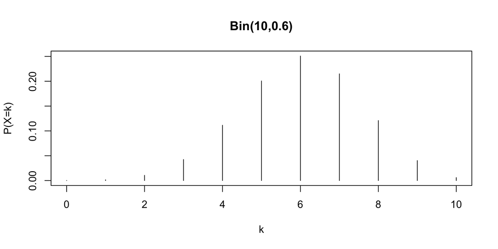

```r
kk <- 0:n
prob <- dbinom(0:n, size = n, prob = p)

plot(kk, prob, type = "h", main = "Bin(10,0.6)", xlab = "k", ylab = "P(X=k)")
```

## Variabile aleatoria normale

Sia $X \sim \text{N}(\mu, \sigma^2)$ una variabile Gaussiana di media $\mu$ e varianza $\sigma^2$, ovvero avente densità

$$f(x) = \frac{1}{\sqrt{2 \pi \sigma^2}}\exp\left\{-\frac{1}{2\sigma^2}(x - \mu)^2\right\}.$$
Se $X \sim (3, 10)$ allora possiamo calcolare il valore di $f(1)$ utilizzando i comandi di **R** nel modo seguente:

```r
x <- 1 # Punto in cui calcolare f(x)
mu <- 3 # Media
sigma2 <- 10 # Varianza


# Calcolo diretto
1 / sqrt(2 * pi * sigma2) * exp(-1 / (2 * sigma2) * (x - mu)^2)
[1] 0.1032883

# Nota: il comando dnorm chiede come input lo scarto quadratico medio, non la varianza
dnorm(x, mean = 3, sd = sqrt(sigma2))
[1] 0.1032883
```

### Funzione di ripartizione e quantili

Sia $X \sim \text{N}(0,1)$ una normale standard. Siamo interessati a calcolare la probabilità dell’evento seguente:

$$\mathbb{P}(|X| \le 1) = \mathbb{P}(-1 \le X \le 1) = \mathbb{P}(X \le 1) - \mathbb{P}(X < -1).$$
Trattandosi di una variabile continua, otteniamo che $\mathbb{P}(X < -1) = \mathbb{P}(X \le -1)$. Pertanto, possiamo calcolare questa probabilità in **R** come segue

```r
pnorm(1) - pnorm(-1)
[1] 0.6826895
```

La continuità della funzione di ripartizione $F(x)$ implica che $\mathcal{Q}(\cdot) = F^{-1}(\cdot)$. Per esempio, il terzo quartile di una distribuzione normale standard, ovvero

```r
qnorm(0.75)
[1] 0.6744898
```

è tale che $F(\mathcal{Q}(0.75)) = F(F^{-1}(0.75))= 0.75$. Infatti:

```r
pnorm(qnorm(0.75))
[1] 0.75
```

## Rappresentazione grafica

Vogliamo ora rappresentare il grafico della densità $f(x)$ di una normale standard nell’intervallo $(-3,3)$. In **R** una qualsiasi funzione può essere rappresentata tramite il comando `curve`.

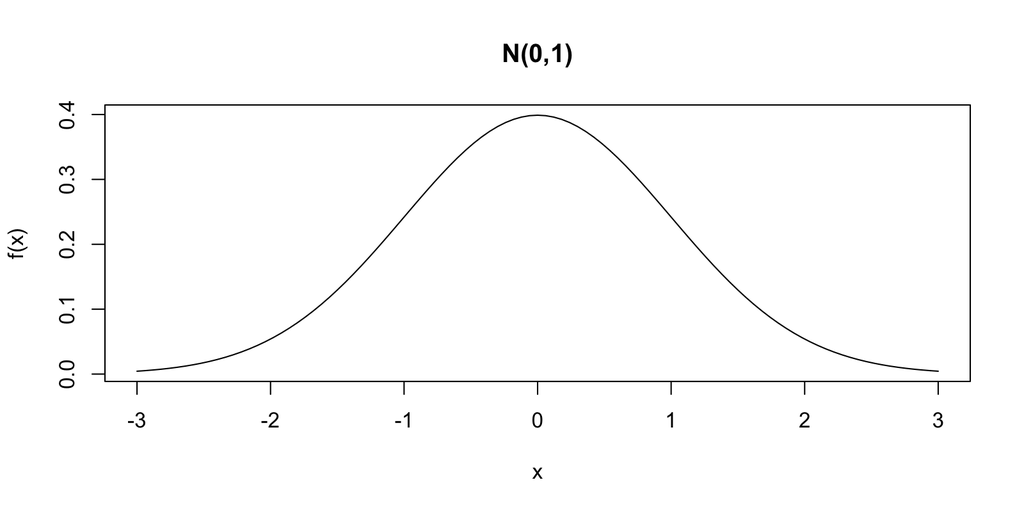

```r
curve(dnorm(x, mean = 0, sd = 1), from = -3, to = 3, ylab = "f(x)", main = "N(0,1)")
```

## Simulazione di valori casuali

La quarta classe di funzioni nella nostra lista è quella del tipo `rdist`, che permette quindi di ottenere un valore “casuale” da una distribuzione.

Per esempio, per campionare $5$ valori indipendenti e identicamente distribuiti (iid) da una normale standard, ovvero

$$X_i \overset{\text{iid}}{\sim} \text{N}(0,1), \qquad i=1,\dots,5$$
possiamo usare in **R** il comando seguente:

```r
R <- 5
rnorm(R, mean = 0, sd = 1)
[1] -0.24545868  0.03099946 -0.21968610 -0.18104241 -1.02376774
```

Questo tipo di operazione è enormemente utile per compiere **studi di simulazione**.

## Numeri pseudo-casuali

I valori generati dal comando `rdist` imitano i risultati di un processo casuale, ma sono in realtà deterministici. I dati sono infatti completamente prevedibili.

Dal momento che i numeri generati sono deterministici, questi vengono chiamati **pseudo-casuali**. Si tratta di sequenze di numeri deterministici che devono sembrare casuali.

È quindi possibile impostare ad uno stato iniziale il generatore di numeri pseudo-casuali attraverso la funzione `set.seed`

```r
set.seed(246135) # Imposto il valore iniziale
rnorm(5, mean = 0, sd = 1)
[1] -0.74639441  0.82913104 -1.11552024  0.03618281 -0.07858270

set.seed(246135) # Re-imposto il valore iniziale
rnorm(5, mean = 0, sd = 1)
[1] -0.74639441  0.82913104 -1.11552024  0.03618281 -0.07858270
```

## Lancio di un dado

Un dado a sei facce rappresenta una variabile casuale $X$ con funzione di probabilità Uniforme Discreta, ovvero

$$\mathbb{P}(X = x) = \frac{1}{6}, \qquad x=1,\dots,6.$$

Per effettuare l’ipotetico lancio di un dado a sei facce, costruiamo un vettore contenente una sequenza di numeri da 1 a 6 corrispondenti ai possibili esiti del lancio.

```r
dice <- 1:6
```

## Il comando `sample`

Per lanciare il dado, si può utilizzare la funzione `sample(x, size, replace, prob)`, che restituisce un campione

1. con reinserimento (`replace=TRUE`);
2. senza reinserimento (`replace=FALSE`);

di ampiezza `size` degli elementi di `x`. Se l’argomento `prob` non viene specificato, la funzione assegna ad ogni elemento di `x` uguale probabilità.

Se volessimo campionare con probabilità non uniformi, dovremmo indicare un vettore di probabilità di lunghezza pari agli elementi di `x`.

```r
sample(x = dice, size = 1)
[1] 6
```

Lanciare il dado $n$ volte consecutive corrisponde a considerare una sequenza di variabili aleatorie $X_1,\dots,X_n$ indipendenti ed identicamente distribuite, ovvero un campionamento **con reinserimento** di ampiezza $n$ dal dado.

```r
n <- 10
x <- sample(dice, size = n, replace = TRUE)
x
 [1] 5 4 4 5 4 6 4 3 4 3
```

### Campionamento senza reinserimento

Se specifichiamo solamente

```r
sample(dice)
[1] 6 1 3 5 4 2
```

otteniamo una **permutazione** casuale degli elementi di `x`, poichè di default `replace=FALSE`.

Ad esempio, per effettuare una ipotetica estrazione del Lotto, si devono estrarre da un’urna 5 numeri, tra l’1 e il 90, senza reinserimento:

```r
sample(1:90, size = 5, replace = FALSE)
[1] 77 83 24 21 62
```

## Analisi dei dati simulati

Le realizzazioni delle variabili aleatorie $X_i \overset{\text{iid}}{\sim}\text{N}(0,1)$, per $i=1,\dots,n$ seguono una distribuzione di tipo gaussiano.

Intuitivamente, ci aspettiamo quindi che la densità dell’istogramma costruito sui dati simulati assomigli alla densità teorica della distribuzione.

```r
set.seed(100)
n <- 10^5 # Numero elevato di simulazioni

x <- rnorm(n) # Simulazione delle variabili aleatorie
```

Se costruiamo l’istogramma e sovrapponiamo la curva della densità, notiamo che in effetti le due densità sono molto simili tra loro.

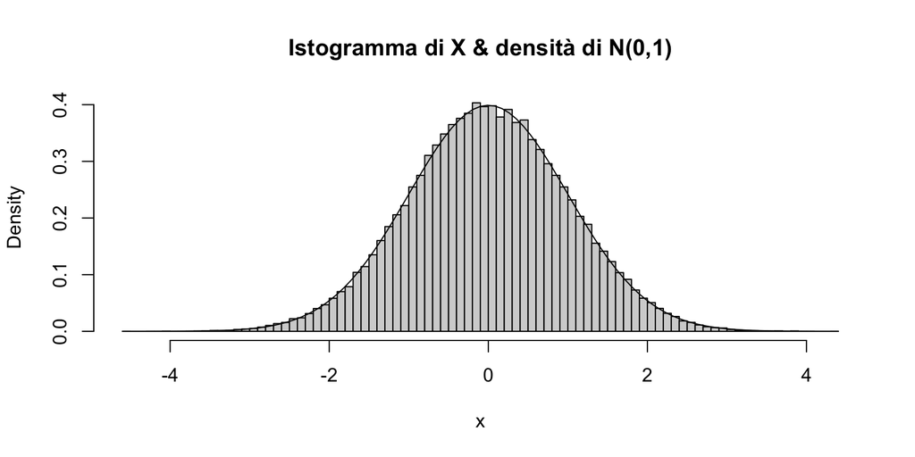

```r
hist(x,
  freq = FALSE,
  breaks = 100,
  main = "Istogramma di X & densità di N(0,1)"
)
curve(dnorm(x), add = TRUE) # add = TRUE implica che la curva viene aggiunta al grafico precedente
```

**Nota**. È molto importante in questo caso usare l’opzione `freq = FALSE`. Lo studente si convinca che non avrebbe senso confrontare $f(x)$ nel caso `freq = TRUE`.

Si noti inoltre che media, mediana e quartili sono prossimi ai valori teorici.

```r
summary(x)
     Min.   1st Qu.    Median      Mean   3rd Qu.      Max.
-4.514481 -0.669717 -0.002325  0.001561  0.673946  4.363243
```

### Un secondo esempio, dati simulati discreti

Siano $X_i \overset{\text{iid}}{\sim}\text{Pois}(10)$, per $i=1,\dots,n$ delle variabili aleatorie di Poisson con media $\lambda = 10$. Confrontiamo quindi la distribuzione di probabilità empirica con quella teorica

```r
n <- 10^5
set.seed(100)
x <- rpois(n, 10) # Simulazione di n variabili Poisson

freq_rel <- table(x) / n # Calcolo delle frequenze relative
```

Il grafico della distribuzione di probabilità si ottiene quindi tramite i seguenti comandi

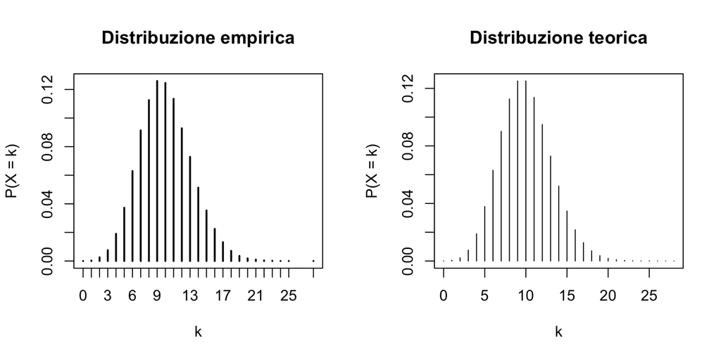

```r
par(mfrow = c(1, 2))
plot(freq_rel, ylab = "P(X = k)", xlab = "k", main = "Distribuzione empirica")
plot(0:28, dpois(0:28, 10), type = "h", ylab = "P(X = k)", xlab = "k", main = "Distribuzione teorica")
```

## Approssimazione di un evento

I risultati del paragrafo precedente sono intuitivamente veri. La loro correttezza deriva però dai risultati della teoria della probabilità.

Sia $X$ una variabile casuale (continua o discreta) e si supponga di voler calcolare la probabilità

$$\mathbb{P}(X \in A),$$
dove $A$ è un evento, ad esempio l’intervallo $A = (0,1]$, il singolo valore $A = 5$, oppure l’intervallo $A = (-\infty, 3]$. Se $X_1,\dots,X_n$ sono delle variabili aleatorie indipendenti ed identicamente distribuite, allora

$$\frac{1}{n}\sum_{i=1}^n \mathbb{I}(X_i \in A) \overset{\text{q.c.}}{\longrightarrow} \mathbb{P}(X_1 \in A), \qquad n \rightarrow \infty.$$
In altri termini, la **proporzione di volte che un evento si verifica nei dati simulati converge** (quasi certamente) **alla probabilità di tale evento**.

### Esempio

Se l’evento è $A = (1,2)$ e le variabili aleatorie sono normali standard indipendenti, ovvero $X_i \overset{\text{iid}}{\sim} \text{N}(0,1)$, allora

$$\frac{1}{n}\sum_{i=1}^n \mathbb{I}(X_i \in (1,2)) \overset{\text{q.c.}}{\longrightarrow} \mathbb{P}(X_1 \in (1,2)) = F(2) - F(1) \approx 0.1359051, \qquad n \rightarrow \infty.$$
Verifichiamo in **R** che se $n$ è elevato, allora la proporzione di volte che si verifica un evento è circa pari alla probabilità teorica

```r
n <- 10^4 # n è un numero grande
set.seed(120)
x <- rnorm(n) # Simulo delle variabili aleatorie normali
```

Dopo aver simulato $X_1,\dots,X_n$, ottengo gli indicatori binari $Y_1,\dots,Y_n$, dove $Y_i = \mathbb{I}(X_i \in (1,2))$. Quindi

```r
# Indicatore binario pari 1 se X è compreso tra 1 e 2 e 0 altrimenti
y <- (x > 1) & (x < 2)
```

Infine, confrontiamo il risultato con il valore teorico

```r
# Proporzione di volte che il risultato si è verificato
mean(y) # Equivalente a: sum(y) / n.
[1] 0.1396
pnorm(2) - pnorm(1)
[1] 0.1359051
```

Per apprezzare il concetto di “convergenza”, possiamo visualizzare le medie $\bar{y}_n = 1/n \sum_{i=1}^ny_i$ al variare di $n$

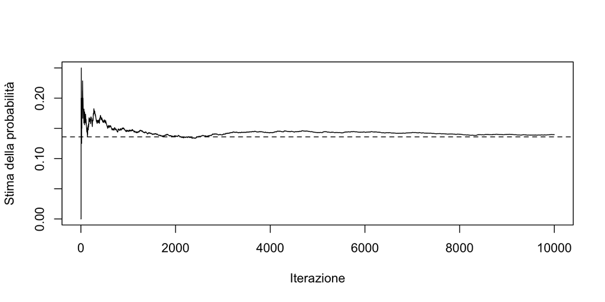

```r
par(mfrow = c(1, 1))
plot(1:n,
  cumsum(y) / 1:n, # Calcolo delle medie al variare di n
  type = "l",
  xlab = "Iterazione",
  ylab = "Stima della probabilità"
)
abline(h = pnorm(2) - pnorm(1), lty = 2) # Disegna una linea orizzontale
```

### Un secondo esempio

La simulazione dell’esempio precedente è poco “utile”, nel senso che è possibile calcolare $\mathbb{P}(X \in (1,2))$, con $X \sim \text{N}(0,1)$, senza dover ricorrere alla simulazione.

In alcuni contesti, tuttavia, la simulazione facilita moltissimo il calcolo. Per esempio, si supponga che
$$A = \{\text{"Numeri naturali divisibili per 7"} \}, \qquad X \sim \text{Pois}(150).$$
Vogliamo calcolare $\mathbb{P}(X \in A)$, ovvero la probabilità che $X$ sia divisibile per $7$.

In **R** possiamo quindi svolgere le seguenti operazioni:

```r
n <- 10^5
set.seed(160)

# Simulo le variabili di Poisson e derivo gli indicatori binari
x <- rpois(n, 150)
y <- (x %% 7) == 0 # Il simbolo %% è la funzione "resto della divisione"
```

Un’approssimazione della probabilità cercata è quindi pari a

```r
mean(y)
[1] 0.14161
```

## La legge dei grandi numeri

Consideriamo ora un risultato teorico di grande importanza, ovvero la legge dei grandi numeri.

Sia $X$ una variabile casuale (continua o discreta) e si supponga di voler calcolare il valore atteso

$$\mathbb{E}(g(X)) < \infty,$$
dove $g(\cdot)$ è una funzione qualsiasi. Se $X_1,\dots,X_n$ sono delle variabili aleatorie indipendenti ed identicamente distribuite, allora

$$\frac{1}{n}\sum_{i=1}^n g(X_i) \overset{\text{q.c.}}{\longrightarrow} \mathbb{E}(g(X)), \qquad n \rightarrow \infty.$$

### Applicazione della legge dei grandi numeri

Se per esempio $X_i \overset{\text{iid}}{\sim} \text{Gamma}(\alpha, \beta)$, allora

$$\frac{1}{n}\sum_{i=1}^n X_i \overset{\text{q.c.}}{\longrightarrow} \frac{\alpha}{\beta}.$$

In **R** possiamo verificare questo teorema come segue

```r
# Definizione dei parametri
alpha <- 3
beta <- 2

n <- 10^5
x <- rgamma(n, shape = alpha, rate = beta)

mean(x) # Stima empirica del valore atteso di X
[1] 1.499245
alpha / beta # Valore atteso teorico di X
[1] 1.5
```

### Un secondo esempio

Nell’esempio precedente, il valore atteso che abbiamo approssimato era facilmente ottenibile tramite calcoli teorici. Tuttavia, questo non sempre accade. Per esempio, si supponga di voler calcolare

$$\mathbb{E}(\sin(X^2)), \qquad X \sim \text{N}(0,1).$$
Il calcolo di questo valore atteso si ottiene semplicemente come segue

```r
n <- 10^5
x <- rnorm(n)
mean(sin(x^2))
[1] 0.354459
```